# Practical Machine Learning - Prediction Assignment Writeup

Shresth Juyal

2/06/2022

## Introduction

This is a Prediction Assignment Writeup for the Coursera course “Practical Machine Learning”. This report will attempt to preduct the classe variable in the training set, which will then be very verified by the testing set. This report will explain how I built the model and also show the expected sample error. In the end, I will use my predication model to preduct 20 test cases given in the test case file.

## Loading Libraries

```r
library(lattice)
library(ggplot2)
library(caret)
library(kernlab)
library(rattle)
library(corrplot)
set.seed(4234)
```

## Importing Data sets and Cleaning Data Set

#### After loading the csv files, I will atempt the clean the data set by removing certain varialbes which have no significance and will not contribute to my prediction model.

```r
training_set = read.csv("/Users/shresthjuyal/data/pml-training.csv")
test_set = read.csv("/Users/shresthjuyal/data/pml-testing.csv")

dim(test_set)
```

```
## [1]  20 160
```

```r
training_set = training_set[,colMeans(is.na(training_set)) < .9]
training_set = training_set[,-c(1:7)]

zerovariance = nearZeroVar(training_set)
training_set <- training_set[,-zerovariance]
dim(training_set)
```

```
## [1] 19622    53
```

```r
inTrain = createDataPartition(y=training_set$classe, p=0.7, list=F)
train = training_set[inTrain,]
valid = training_set[-inTrain,]
```

## Creating Decision Tree

[figure not shown]

```r
control = trainControl(method="cv", number=3, verboseIter=F)

decision_tree <- train(classe~., data=train, method="rpart", trControl = control, tuneLength = 5)
fancyRpartPlot(decision_tree$finalModel)
```

## Creating First Prediction Model

```r
pred_trees = predict(decision_tree, valid)
cmtrees = confusionMatrix(pred_trees, factor(valid$classe))
cmtrees
```

```
## Confusion Matrix and Statistics
##
##           Reference
## Prediction    A    B    C    D    E
##          A 1527  459  485  416  151
##          B   23  359   39   16  127
##          C   84  129  423  132  128
##          D   37  192   79  400  173
##          E    3    0    0    0  503
##
## Overall Statistics
##
##                Accuracy : 0.5458
##                  95% CI : (0.533, 0.5586)
##     No Information Rate : 0.2845
##     P-Value [Acc > NIR] : < 2.2e-16
##
##                   Kappa : 0.4084
##
##  Mcnemar's Test P-Value : < 2.2e-16
##
## Statistics by Class:
##
##                      Class: A Class: B Class: C Class: D Class: E
## Sensitivity            0.9122  0.31519  0.41228  0.41494  0.46488
## Specificity            0.6412  0.95681  0.90265  0.90226  0.99938
## Pos Pred Value         0.5026  0.63652  0.47210  0.45403  0.99407
## Neg Pred Value         0.9484  0.85341  0.87913  0.88729  0.89236
## Prevalence             0.2845  0.19354  0.17434  0.16381  0.18386
## Detection Rate         0.2595  0.06100  0.07188  0.06797  0.08547
## Detection Prevalence   0.5162  0.09584  0.15225  0.14970  0.08598
## Balanced Accuracy      0.7767  0.63600  0.65747  0.65860  0.73213
```

```r
mod = train(classe~., data=train, method="rf", trControl = control, tuneLength = 5)

tree_prediction <- predict(mod, valid)
tree <- confusionMatrix(tree_prediction, factor(valid$classe))
tree
```

```
## Confusion Matrix and Statistics
##
##           Reference
## Prediction    A    B    C    D    E
##          A 1672    3    0    0    0
##          B    2 1130   14    0    0
##          C    0    6 1008    6    3
##          D    0    0    4  956    3
##          E    0    0    0    2 1076
##
## Overall Statistics
##
##                Accuracy : 0.9927
##                  95% CI : (0.9902, 0.9947)
##     No Information Rate : 0.2845
##     P-Value [Acc > NIR] : < 2.2e-16
##
##                   Kappa : 0.9908
##
##  Mcnemar's Test P-Value : NA
##
## Statistics by Class:
##
##                      Class: A Class: B Class: C Class: D Class: E
## Sensitivity            0.9988   0.9921   0.9825   0.9917   0.9945
## Specificity            0.9993   0.9966   0.9969   0.9986   0.9996
## Pos Pred Value         0.9982   0.9860   0.9853   0.9927   0.9981
## Neg Pred Value         0.9995   0.9981   0.9963   0.9984   0.9988
## Prevalence             0.2845   0.1935   0.1743   0.1638   0.1839
## Detection Rate         0.2841   0.1920   0.1713   0.1624   0.1828
## Detection Prevalence   0.2846   0.1947   0.1738   0.1636   0.1832
## Balanced Accuracy      0.9990   0.9944   0.9897   0.9951   0.9970
```

## Creating Second Prediction Model

```r
second <- train(classe~., data=train, method="gbm", trControl = control, tuneLength = 5, verbose = F)

second_prediction <- predict(second, valid)
plot_second <- confusionMatrix(second_prediction, factor(valid$classe))
plot_second
```

```
## Confusion Matrix and Statistics
##
##           Reference
## Prediction    A    B    C    D    E
##          A 1664    5    0    0    0
##          B    9 1121   16    1    0
##          C    0   13  999    8    3
##          D    0    0   10  952    5
##          E    1    0    1    3 1074
##
## Overall Statistics
##
##                Accuracy : 0.9873
##                  95% CI : (0.9841, 0.99)
##     No Information Rate : 0.2845
##     P-Value [Acc > NIR] : < 2.2e-16
##
##                   Kappa : 0.9839
##
##  Mcnemar's Test P-Value : NA
##
## Statistics by Class:
##
##                      Class: A Class: B Class: C Class: D Class: E
## Sensitivity            0.9940   0.9842   0.9737   0.9876   0.9926
## Specificity            0.9988   0.9945   0.9951   0.9970   0.9990
## Pos Pred Value         0.9970   0.9773   0.9765   0.9845   0.9954
## Neg Pred Value         0.9976   0.9962   0.9944   0.9976   0.9983
## Prevalence             0.2845   0.1935   0.1743   0.1638   0.1839
## Detection Rate         0.2828   0.1905   0.1698   0.1618   0.1825
## Detection Prevalence   0.2836   0.1949   0.1738   0.1643   0.1833
## Balanced Accuracy      0.9964   0.9894   0.9844   0.9923   0.9958
```

```r
predicted <- predict(mod, test_set)
print(predicted)
```

```
##  [1] B A B A A E D B A A B C B A E E A B B B
## Levels: A B C D E
```

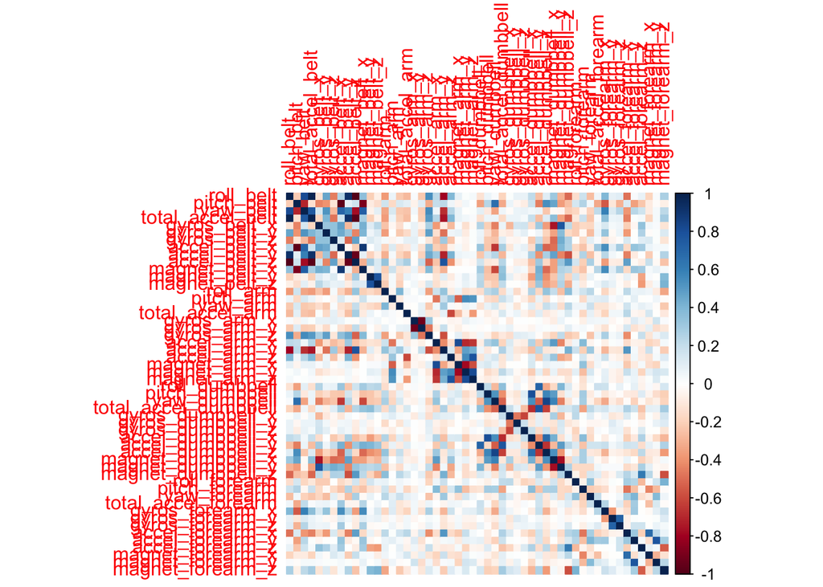

```r
correlation = cor(train[, -length(names(train))])
corrplot(correlation, method="color")
```